← BlogJieming Li

On this page

Research notebook · 研究笔记

# 从 World Models 到 Dreamer 4：在世界模型里学习行动

这组图片讲的是一条很清楚的研究主线：**先学习“采取动作之后会发生什么”，再利用预测出来的经验改进策略。** 难点逐渐从“能不能在模型里学”，转向“怎样记住历史、怎样高效优化策略、怎样跨任务稳定训练，以及怎样利用大规模离线视频”。

本文按内容顺序保存了全部 15 张原图，并在相应位置补充解释。原图为用户提供的二手阅读材料，保留原貌；补充部分依据文末一手资料核对。原图中的所有排行榜数字和实现参数并未逐项复现，未确认的数值不会作为本文结论。

**图片保存方式：15 张 JPEG 的完整数据已嵌入本 Markdown，删除 Downloads 中的原图不会影响数据保存。部分 Markdown 阅读器会限制内嵌图片，因此另附同样自包含的 HTML 阅读版。两个文件均不依赖外部图片文件。**

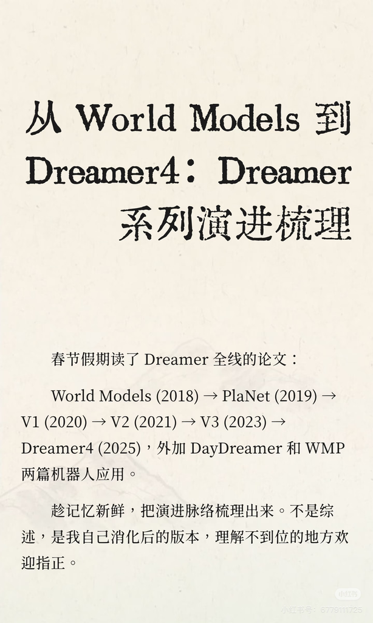

## 1. 先把整条路线放在一起

| 工作 | 最值得记住的变化 | 世界模型主要用来做什么 |
| --- | --- | --- |
| World Models，2018 | 视觉压缩、循环预测、小控制器 | 提供动态表征，并展示在学习到的环境中训练控制器 |
| PlaNet，2018 预印本 / ICML 2019 | RSSM 与潜在空间规划 | 对候选动作序列预测回报 |
| Dreamer V1，2019 预印本 / ICLR 2020 | 想象中的 actor-critic | 将未来回报的梯度用于学习策略 |
| Dreamer V2，ICLR 2021 | 离散随机潜变量、KL balancing | 改进世界模型及策略学习 |
| Dreamer V3，2023 预印本 | 跨量级目标和训练稳定性 | 用统一算法配置适应多类任务 |
| Dreamer 4，2025 | Transformer 动态模型、Shortcut Forcing、离线学习 | 利用大规模离线经验训练交互模型和策略 |
| DayDreamer | 真实机器人上的在线学习 | 减少真实交互需求 |
| WMP | 用世界模型学习感知状态 | 为在仿真中训练的运动策略提供输入 |

这里按图片的命名使用 V1、V2、V3；不同文章会按预印本或会议年份记年，不能仅因年份不同就判断是另一篇论文。

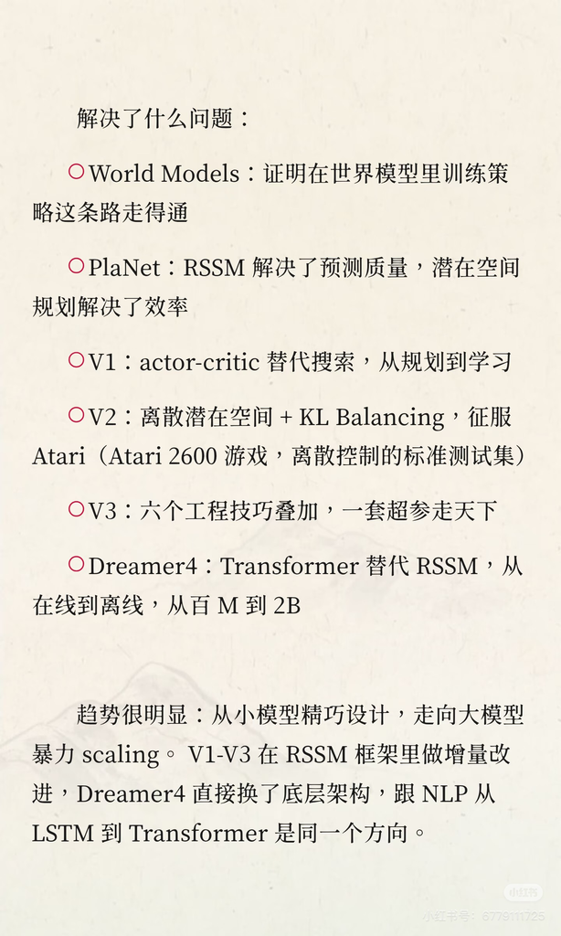

这条路线有连续性，但不能简化成“模型越来越大，所以越来越好”。策略优化、训练数据来源、动作条件、预测成本和评测协议也在变化。尤其 V3 与 Dreamer 4 的 Minecraft 结果，必须连同在线/离线条件一起读。

## 2. World Models：压缩画面、预测变化、训练控制器

最早这篇的结构非常直观：V 负责把图像压成 latent，M 负责根据历史和动作预测下一步，C 负责选动作。

$$z_t=E(o_t),\qquad
p(z_{t+1}\mid z_t,a_t,h_t),\qquad
a_t=C(z_t,h_t).$$

这里的 $z_t$ 描述当前画面，$h_t$ 包含过去观测与动作积累的信息。例如单帧能看见车在弯道哪里，历史则有助于判断它正在往哪个方向偏。

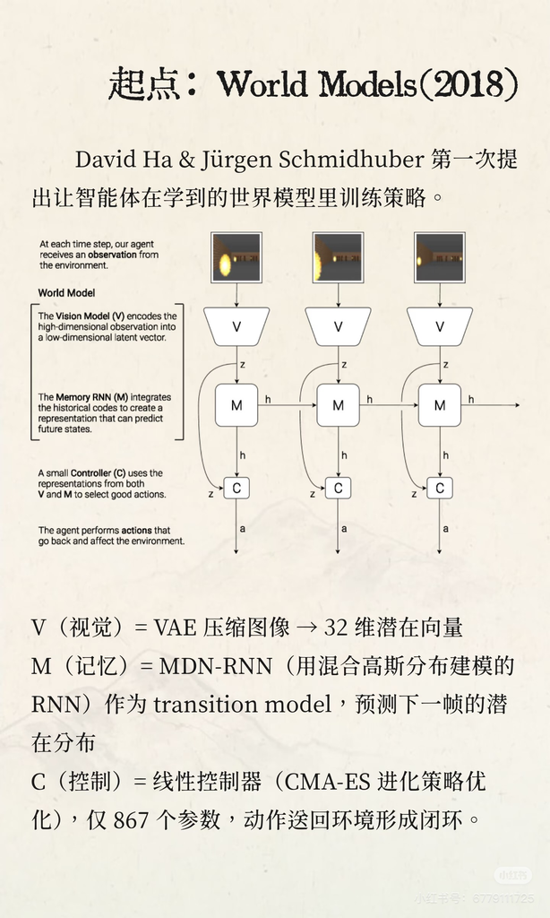

图片中的 32 维 latent 和 867 参数控制器，对应原论文 CarRacing 配置，不能当成所有实验的统一结构。MDN-RNN 输出混合高斯分布，用来表达未来的不确定性。[World Models 原文](https://worldmodels.github.io/)

### “在梦里训练”需要哪些真实信息

它首先需要环境数据来训练视觉和动态模型。随后，某些实验中的控制器可以在学习到的模拟环境里优化，再放回原环境测试。

因此“训练控制器时不接触原环境”与“完全不需要环境数据”不同。世界模型能预测什么，仍取决于之前看过哪些轨迹。

还要注意模型漏洞：如果策略找到一种动作，让预测模型持续给出好结果，但真实环境根本不会如此发展，想象中的高回报就失去了意义。后面各代方法都需要面对这一问题。

## 3. PlaNet：用 RSSM 同时保存历史和不确定性

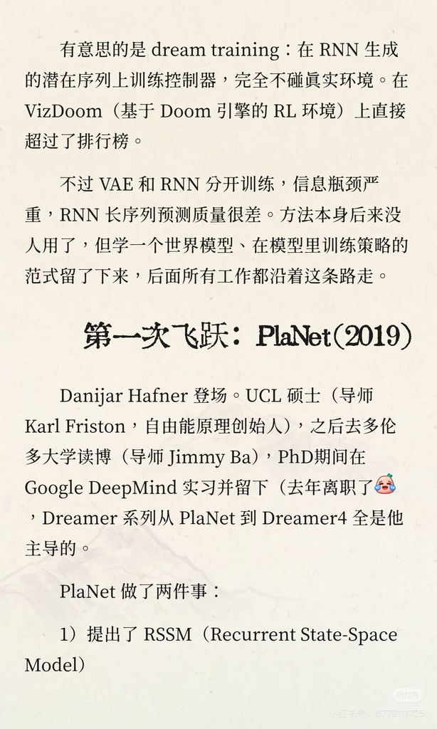

图中把 World Models 称为“第一次提出在世界模型中训练策略”，这个历史定位过强。基于学习模型进行规划、学习行为的思想早于 2018 年；这篇是深度潜在世界模型路线的重要代表。

PlaNet 的 RSSM（Recurrent State-Space Model）可以理解为：用一个递归状态保存历史，再加一个随机变量表达当前状态中无法完全确定的部分。

为了避免与真实环境状态混淆，这里用 $h_t$ 表示确定性记忆，$z_t$ 表示随机 latent：

$$h_t=f_\theta(h_{t-1},z_{t-1},a_{t-1}).$$

看到真实观测时，计算后验：

$$q_\theta(z_t\mid h_t,o_t).$$

想象未来、没有真实观测时，使用先验：

$$p_\theta(z_t\mid h_t).$$

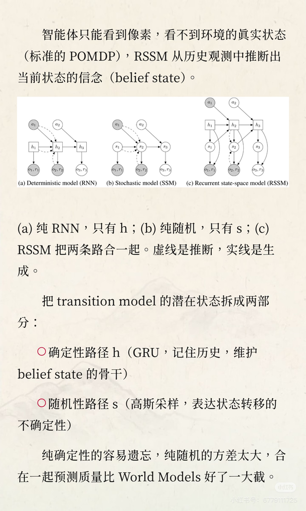

### 先验和后验到底差在哪里

先验是在“还没看到下一帧”时，根据过去预测现在可能是什么样。后验是在看到当前图像后，把这个预测修正得更具体。

训练时两者都存在，KL 项把它们联系起来：让没有图像输入的动态预测尽量跟上有图像输入的状态推断。部署时每获得一帧真实观测，就可以重新修正内部状态。

因此 RSSM 的状态有点像对环境的信念表示，但它是学习到的近似，不能直接等同于数学上精确的 POMDP belief distribution。

图片用“纯确定性容易遗忘、纯随机方差大”帮助记忆。更准确地说，这两类路径提供不同的建模方式：确定性状态提供稳定的信息传递，随机变量允许表示多种可能。是否遗忘、预测多准，还取决于结构、目标和数据。

## 4. PlaNet 的规划：每次搜索，但执行时持续重规划

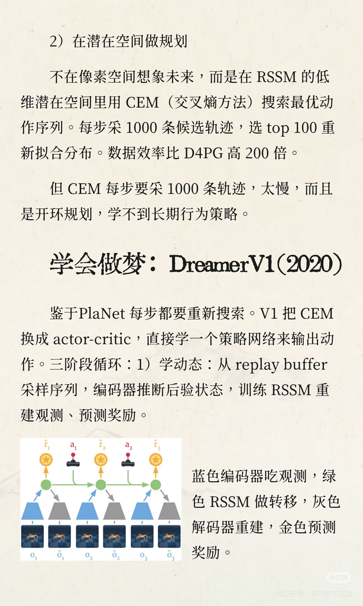

在潜在空间中，规划不需要把每个未来状态都解码成高清图片。只要模型能预测动作对应的状态变化与奖励，就能给候选动作序列评分。

CEM 的基本过程是：先采样一批动作序列，在模型里展开，选出回报较高的候选，再用这些候选更新采样分布，重复若干轮。

$$\hat a_{t:t+H-1}
\approx\arg\max_{a_{t:t+H-1}}
\mathbb E\!\left[\sum_{k=0}^{H-1}\gamma^k\hat r_{t+k}\right].$$

**重要纠正：候选序列内部是开环评估，但 PlaNet 实际采取滚动时域控制。** 执行当前选出的动作、得到新观测后，会重新估计状态并规划。因此不能把整个 PlaNet 说成没有反馈的开环控制。[PlaNet](https://arxiv.org/abs/1811.04551)

它的主要计算代价是每次都要进行候选搜索。Dreamer 接下来要解决的，是能不能把“什么状态应该选什么动作”直接学成一个网络，使执行时不必重新完成这套搜索。

## 5. Dreamer V1：把想象经验用来训练 actor 和 critic

Dreamer 把工作分成三个循环：学习世界模型、在模型内学习行为、回到环境收集新经验。

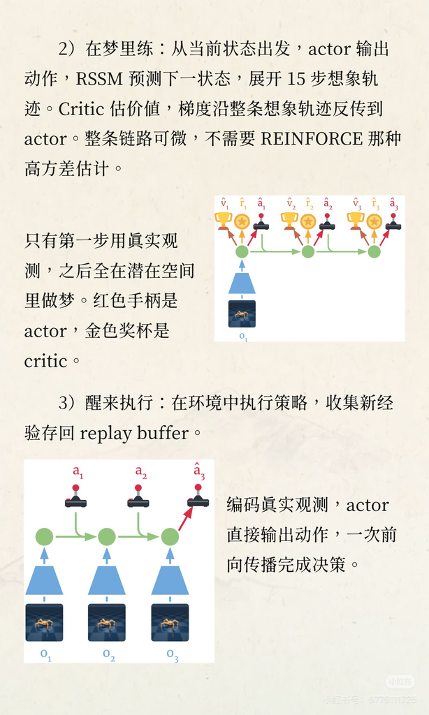

### 第一步：世界模型学会预测

从 replay buffer 取真实轨迹，利用后验推断状态，学习重建观测、预测奖励，并让先验与后验相容。概念上可以写成：

$$\mathcal{L}_{\mathrm{model}}
=\mathcal{L}_{\mathrm{obs}}+\mathcal{L}_{\mathrm{reward}}
+\beta\,D_{\mathrm{KL}}(q\Vert p).$$

这只是帮助理解的简化式；不同版本还有延续概率等预测头及不同的损失权重。

### 第二步：从真实状态出发，在模型中展开未来

actor 根据当前 latent 采样动作，世界模型预测下一状态，奖励模型给出预测奖励，critic 估计更长远的收益。

一个常见的回报表达是：

$$G_t^\lambda=\hat r_t+\gamma\big[(1-\lambda)V(s_{t+1})+\lambda G_{t+1}^\lambda\big].$$

这里用 $s_t=(h_t,z_t)$ 简写模型状态；实际实现还会处理终止与延续概率。critic 的作用是为有限长度的想象提供更远期的价值估计。

V1 的一个关键点是利用可微动态，把未来价值对动作的影响传回 actor。**冻结世界模型参数，不等于切断动作经过世界模型的梯度。** 一个固定函数仍然可以对输入求导。[Dream to Control](https://arxiv.org/abs/1912.01603)

### 第三步：回到环境验证并继续收集数据

执行时先根据真实观测更新内部状态，再由 actor 生成动作。新经验进入 replay buffer，纠正模型当前没学好的区域。

“在想象中训练策略”说的是策略更新的数据与计算路径；经典 Dreamer 的总体训练仍然包含真实环境或基准模拟器中的数据收集。

## 6. Dreamer V2：离散 latent 与 KL balancing

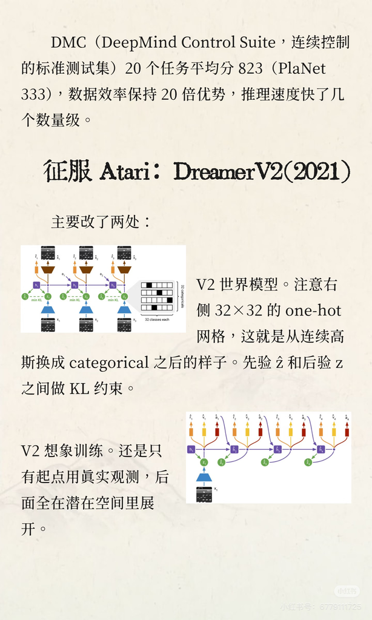

V2 将随机 latent 改成一组 categorical 变量。图片给出的典型配置是 32 个变量、每个 32 类。这是多个分类变量的组合，不是一个只有 32 类的整体状态。

离散采样不可直接微分，可以用 straight-through estimator：前向使用采样得到的 one-hot，反向用连续概率提供近似梯度。

$$z=\operatorname{sg}(z_{\mathrm{onehot}}-p)+p.$$

$\operatorname{sg}$ 表示停止梯度。这个估计是有偏近似，价值在于使训练可行，不能理解为离散采样突然变成了严格可微。

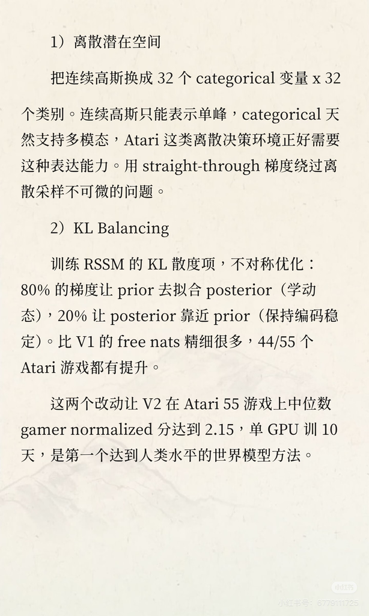

### KL balancing 分配的是哪条梯度

可以用下面的形式理解：

$$\mathcal{L}_{\mathrm{KL}}
=\alpha D_{\mathrm{KL}}(\operatorname{sg}(q)\Vert p)
+(1-\alpha)D_{\mathrm{KL}}(q\Vert\operatorname{sg}(p)).$$

第一项主要让先验学习后验，第二项主要约束后验。图片中的 0.8/0.2 是损失权重的直观说明，不能理解为实际梯度范数精确按 80%/20% 分配。两项的梯度大小还由分布和网络决定。[Dreamer V2](https://danijar.com/project/dreamerv2/)

图片里“连续高斯只能单峰，所以 categorical 更适合离散环境”的说法也需要缩小范围：单个高斯确实单峰，但连续潜变量配合非线性映射或混合分布同样可以表示复杂、多模态结果。离散 latent 的收益是经验结果，不是由动作空间离散性直接推出的定理。

另一个常见误解是把 V1 的梯度路径照搬到所有后续版本。不同版本、连续与离散动作设置，对 dynamics gradient 和 score-function gradient 的使用会变化，复现时应逐版查看 actor loss。

## 7. Dreamer V3：让训练配方适应不同任务的量级

[figure not shown]

V3 继续使用 RSSM 路线，重点处理跨任务训练中的数值和优化问题：一个环境奖励很小，另一个很大；有些回报稀疏，有些密集；预测目标的尺度也不同。

### symlog：保留符号，压缩大数

$$\operatorname{symlog}(x)=\operatorname{sign}(x)\ln(1+|x|).$$

它在零附近比较接近原值，在绝对值很大时压缩尺度。这样模型不必因为目标数值差几个数量级，就承受完全不同量级的回归误差。

### two-hot：让连续目标落在两个相邻桶上

$$w_i=\frac{b_{i+1}-y}{b_{i+1}-b_i},\qquad
w_{i+1}=\frac{y-b_i}{b_{i+1}-b_i}.$$

例如桶值是 2 和 4，目标是 2.5，两个权重就是 0.75 与 0.25。输出变成分类概率，训练目标仍保留连续数值的位置。

two-hot 标签本身不是“不确定性真值”；它首先是一种连续标量的分布式编码。模型输出的分布是否反映可靠的不确定性，需要另外检验。

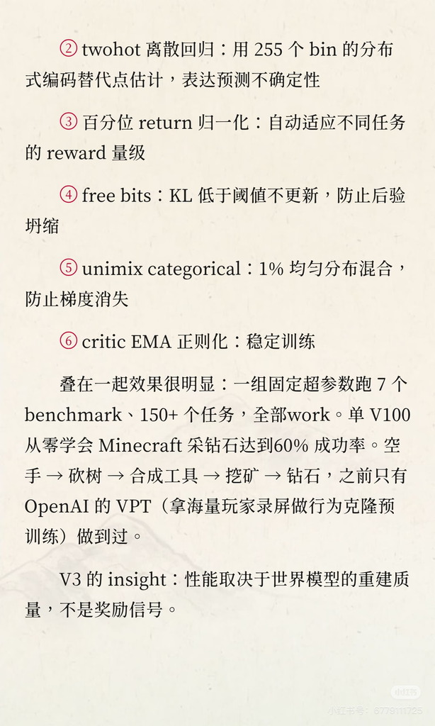

### 其他稳定性设计怎样理解

| 设计 | 实际作用 | 容易误读的地方 |
| --- | --- | --- |
| 回报尺度归一化 | 调整策略学习信号的尺度 | 不等于把不同任务的语义变成一样 |
| Free bits / free nats | KL 小于阈值后，不再奖励继续压小该项 | 其他损失仍然更新网络 |
| Unimix | 在 categorical 概率中混入少量均匀分布 | 主要避免概率过度尖锐和数值不稳定，不能保证所有梯度不消失 |
| 慢速 critic / EMA 正则 | 缓和价值目标变化 | 不等于价值估计永远正确 |

“一套超参”指一套算法配置能在多个任务中训练，不是一个固定 checkpoint 已经同时掌握所有任务。V3 的配置鲁棒性，与多任务基础模型的能力覆盖，是不同的问题。[Dreamer V3](https://arxiv.org/abs/2301.04104)

原图最后把 insight 写成“性能取决于重建质量，不是奖励信号”，这不宜作为一般结论。重建有助于学习丰富状态，但策略仍需要任务目标。低像素误差也可能主要来自背景预测，不能单独证明模型学会了奖励相关事件或接触动力学。

## 8. Dreamer 4：把大规模视频模型变成可交互的训练环境

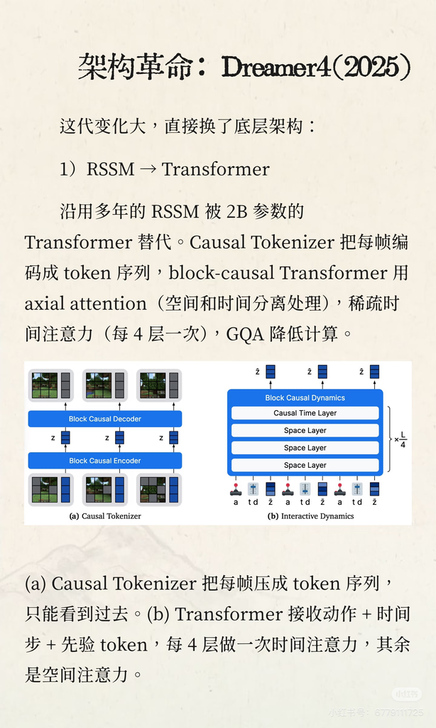

Dreamer 4 更换了主要动态模型架构，使用因果 tokenizer 和 Transformer 在动作条件下预测未来 latent。图片强调的 2B 规模只是其中一部分；另一个关键要求是预测足够快，否则世界模型再准确，也难以产生大量策略训练经验。

### 因果性解决什么问题

在线预测时只能用已经看到的历史。如果训练表征能偷看未来，部署时就会失去这些信息。时间上的因果结构使训练和实际交互时可用的信息更一致。

空间注意力处理同一帧内的关系，时间注意力处理历史变化。把两种注意力分开组织，可以减少全时空注意力的成本。具体层比例、分辨率和吞吐量都属于实现配置，不能跨模型直接照搬。

### Shortcut Forcing 为什么重要

普通多步生成过程会反复运行网络。如果每模拟一个环境步骤都需要很多次去噪，那么策略学习的成本很高。

Shortcut Forcing 让模型学习不同生成步长，通过自举一致性缩短采样过程。需要区分：这里的“去噪步数”是生成模型内部的迭代次数，不是智能体走了多少个环境步骤。

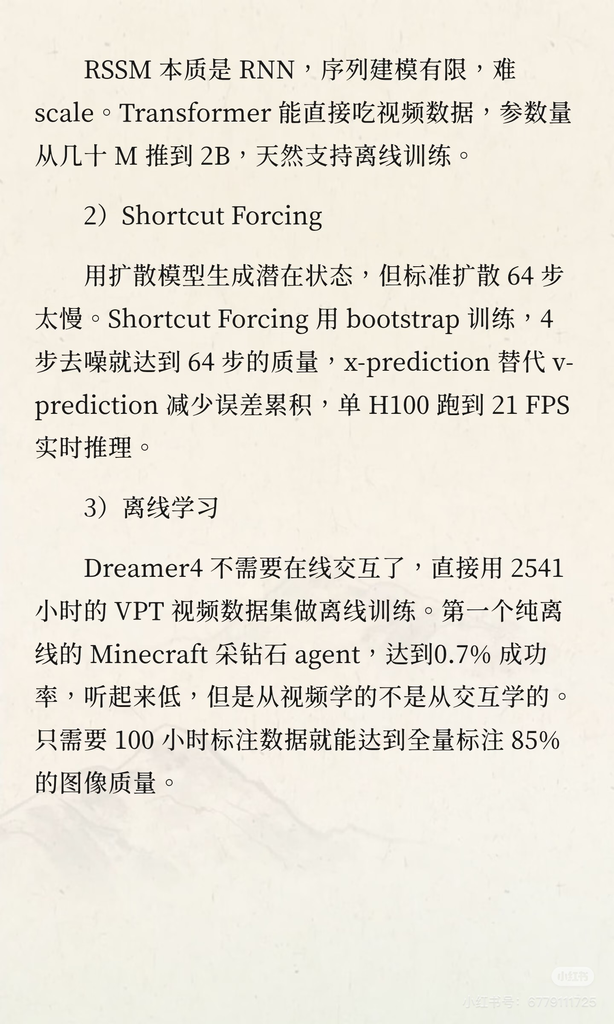

### 离线学习仍然要处理动作和奖励

Dreamer 4 的目标是在固定离线经验上学世界模型，再在模型内改进策略，避免训练中继续向原环境索取新交互。

**离线不等于所有数据都没有动作，也不等于没有 RL。** 无动作视频可以贡献视觉动态知识，但学习“我按这个键会发生什么”仍需要动作条件的约束；想象中的 RL 还需要任务与奖励模型。

原文报告离线 Minecraft 获得钻石的成功率为 0.7%。这是一个特定困难协议下的可行性结果，不能与原图给出的 V3 在线训练成功率直接排行。[Dreamer 4 原文](https://arxiv.org/html/2509.24527v1)

还要避免把 21 FPS 等交互模拟吞吐量直接换成机器人闭环控制频率。完整系统还包括输入处理、策略、硬件通信和动作执行，这些都可能增加延迟。

### 两处原图数字暂不照抄

“4 步达到 64 步质量”需要绑定具体质量指标和采样设置；“100 小时达到 85% 图像质量”也需要明确 85% 是什么指标、相对哪个基线。本文保留原图，但不将这些描述作为已核对的精确实验结论。

## 9. DayDreamer 与 WMP：世界模型在机器人中的两种用法

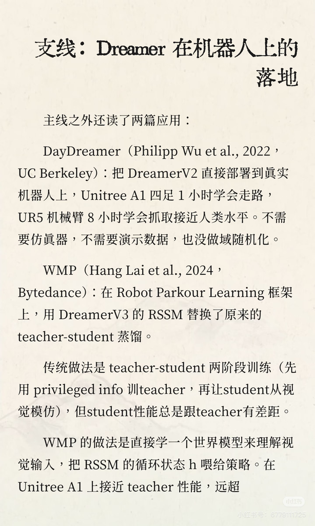

DayDreamer 研究直接在真实机器人上收集经验和学习。它的价值在于减少真实交互需求，并让学到的模型适应真实硬件，而不是完全依赖预先搭建的模拟器。[DayDreamer](https://arxiv.org/abs/2206.14176)

原图里的小时数对应具体平台和实验，不能理解为任意机器人上线后都能在同样时间内学会走路或抓取。真机学习还涉及奖励、复位、数据吞吐和系统可靠性。

### WMP 并不是把完整 Dreamer 训练循环搬到四足机器人

WMP 用世界模型的循环状态作为策略输入，帮助策略利用视觉和本体历史理解地形。**它的 actor-critic 用模拟器轨迹训练，采用 PPO；原文明确没有用世界模型生成策略训练 rollout。** critic 训练还使用特权信息，因此“省掉 teacher-student 蒸馏”不等于“整个训练完全不用特权信息”。[WMP 方法](https://arxiv.org/html/2409.16784v1#S4)

这个区别非常有用：

| 用法 | 数据流 | 主要收益 |
| --- | --- | --- |
| 世界模型做规划 | 模型评估候选动作 | 帮助在线选动作 |
| 世界模型做想象训练 | 模型产生策略更新用的未来经验 | 减少外部交互 |
| 世界模型做感知表征 | 模型状态输入策略，策略在外部环境中训练 | 改善部分可观测条件下的状态估计 |

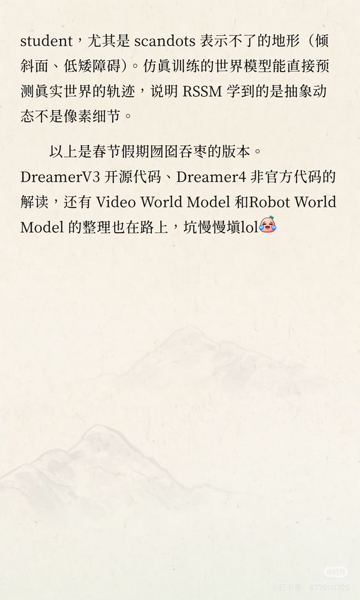

仅凭模型能预测某些真机轨迹，也不能推出已经获得了普适的真实物理规律。更稳妥的结论是：它在所测条件中学到了有迁移价值的动态表征。

## 10. 读这一系列时，最重要的五个区分

**世界模型准不准，与视频好不好看不同。** 控制需要动作后果、奖励事件和终止判断准确。漂亮背景不能补偿抓取状态预测错误。

**训练需要的模型，与部署需要的模型不同。** 想象时可以展开很多未来；实际执行时仍可能只更新当前 latent，再调用 actor。模型参与了训练，不意味着部署每步都要生成未来视频。

**样本效率与计算效率不同。** 更少真实交互可能伴随更多模型训练和想象计算。比较时应同时记环境步数、GPU 时间和墙钟时间。

**开环候选与闭环执行不同。** PlaNet 内部搜索动作序列，不代表它执行时不接受新观测；AMP 写一段轨迹，也不代表轨迹内部能够随时重新推理。

**统一配方与统一权重不同。** V3 的跨任务配置鲁棒性，与一个多任务基础模型无需再训练就完成新任务，不是同一类泛化。

## 11. 对 WAM 和机器人操作的启发

下面是基于这条研究路线的延伸思考。

第一，可以先明确世界模型在系统里的职责：用来生成策略训练数据、在线评估动作，还是提供控制相关表征。职责不同，评估就不同，不能只用视频质量排序。

第二，接触操作应增加针对控制变量的评估。例如夹爪是否真正夹住、物体是否开始滑移、插入是否卡住、动作是否可逆。相同的像素误差，可能对应完全不同的操作风险。

第三，离线训练要特别关注分布外动作。策略优化会主动寻找高回报区域，也可能把世界模型推到没有数据支持的区域。可以比较短时想象、数据约束和少量在线纠正，分别如何影响真实成功率。

第四，不必要求同一个模型同时负责所有时间尺度。快速接触响应、短时动作规划和长时任务记忆可以使用不同模块，再用清楚的状态和目标接口连接。

这组工作持续追问的是：**预测出来的未来，怎样转化成真实环境里更好的行动？** RSSM、actor-critic、离散 latent、稳定训练和 Transformer 分别解决了一部分问题。最终判断仍要回到执行结果，而不是只看模型规模或生成画面。

## 12. 一手资料与阅读顺序

建议先读 World Models 建立直觉，再读 PlaNet 理解先验、后验和 RSSM，随后读 V1 理解想象中的策略优化。V2、V3 重点看训练目标和消融，Dreamer 4 再关注大规模离线数据与交互预测。

- [World Models](https://worldmodels.github.io/)：V/M/C、CarRacing 与梦境训练。
- [PlaNet：Learning Latent Dynamics for Planning from Pixels](https://arxiv.org/abs/1811.04551)：潜在动态与规划。
- [Dreamer V1：Dream to Control](https://arxiv.org/abs/1912.01603)：想象中的行为学习。
- [Dreamer V2：Mastering Atari with Discrete World Models](https://danijar.com/project/dreamerv2/)：离散状态与训练设计。
- [Dreamer V3：Mastering Diverse Domains through World Models](https://arxiv.org/abs/2301.04104)：统一配置；注意预印本与后续版本的差异。
- [Dreamer 4：Training Agents Inside of Scalable World Models](https://danijar.com/project/dreamer4/)：离线世界模型与策略训练。
- [DayDreamer](https://arxiv.org/abs/2206.14176)：真实机器人在线学习。
- [WMP：World Model-based Perception](https://wmp-loco.github.io/)：用动态表征改善视觉运动控制。

整理与关键机制核对日期：2026 年 11 月 12 日。原图编号按 IMG_0850—IMG_0864 排列，完整保留 15 张。